# BCB546_R_Assignment

Issi Burger

2023-03-10

```r
library(tidyverse)
library(janitor)
```

```r
library(ggplot2)
library(magrittr)
fang_genotype <- read_tsv("https://github.com/EEOB-BioData/BCB546_Spring2023/blob/main/assignments/UNIX_Assignment/fang_et_al_genotypes.txt?raw=true")
fang_genotype <- as.data.frame(fang_genotype)
snp_position <- read_tsv("https://github.com/EEOB-BioData/BCB546_Spring2023/raw/main/assignments/UNIX_Assignment/snp_position.txt")
snp_position <- as.data.frame(snp_position[,c(1,3:4)])
```

The code above loads the two files for this assignment into R. I also cut the columns needed from the snp_position.txt.

```r
ncol(fang_genotype)
```

```
## [1] 986
```

```r
nrow(fang_genotype)
```

```
## [1] 2782
```

```r
str(fang_genotype)
```

```
## 'data.frame':    2782 obs. of  986 variables:
##  $ Sample_ID     : chr  "SL-15" "SL-16" "SL-11" "SL-12" ...
##  $ JG_OTU        : chr  "T-aust-1" "T-aust-2" "T-brav-1" "T-brav-2" ...
##  $ Group         : chr  "TRIPS" "TRIPS" "TRIPS" "TRIPS" ...
##  $ abph1.20      : chr  "?/?" "?/?" "?/?" "?/?" ...
##  $ abph1.22      : chr  "?/?" "?/?" "?/?" "?/?" ...
##  $ ae1.3         : chr  "T/T" "T/T" "T/T" "T/T" ...
##  $ ae1.4         : chr  "G/G" "?/?" "G/G" "G/G" ...
##  $ ae1.5         : chr  "T/T" "T/T" "T/T" "T/T" ...
##  $ an1.4         : chr  "C/C" "C/C" "?/?" "C/C" ...
##  $ ba1.6         : chr  "?/?" "A/G" "G/G" "G/G" ...
##  $ ba1.9         : chr  "G/G" "G/G" "G/G" "G/G" ...
##  $ bt2.5         : chr  "?/?" "?/?" "C/C" "C/C" ...
##  $ bt2.7         : chr  "A/A" "A/A" "A/A" "A/A" ...
##  $ bt2.8         : chr  "?/?" "?/?" "?/?" "?/?" ...
```

[output cut: 86 more lines]

The code above describes the fang_genotype.txt docuemnt. There are 986 columns and 2782 rows in this data set. All variables in this data set are classified as characters.

```r
ncol(snp_position)
```

```
## [1] 3
```

```r
nrow(snp_position)
```

```
## [1] 983
```

```r
str(snp_position)
```

```
## 'data.frame':    983 obs. of  3 variables:
##  $ SNP_ID    : chr  "abph1.20" "abph1.22" "ae1.3" "ae1.4" ...
##  $ Chromosome: chr  "2" "2" "5" "5" ...
##  $ Position  : chr  "27403404" "27403892" "167889790" "167889682" ...
```

```r
maize <- subset(fang_genotype, fang_genotype$Group==c("ZMMIL","ZMMLR","ZMMMR"))
maize_transpose <- as.data.frame(t(maize))
maize_transpose <- maize_transpose %>%
  rownames_to_column(var = "SNP_ID")
maize_transpose <- row_to_names(maize_transpose, 1, remove_rows_above = TRUE) %>%
  rename("SNP_ID" = "Sample_ID")
maize_combined <- inner_join(snp_position, maize_transpose, by = "SNP_ID")
maize_combined$Position <- as.numeric(maize_combined$Position)
maize_increasing_chr <- function(x) {
  subset(maize_combined, maize_combined$Chromosome==x) %>%
    arrange(Position)
}

maize_decreasing_chr <- function(x) {
  subset(maize_combined, maize_combined$Chromosome==x) %>%
    arrange(desc(Position))
}



maize_chr1_increasing <- maize_increasing_chr(1)
write.table(maize_chr1_increasing, file = "maize_chr1_increasing", quote = FALSE, sep = "\t", row.names = FALSE, col.names = TRUE)
maize_chr2_increasing <- maize_increasing_chr(2)
write.table(maize_chr2_increasing, file = "maize_chr2_increasing", quote = FALSE, sep = "\t", row.names = FALSE, col.names = TRUE)
maize_chr3_increasing <- maize_increasing_chr(3)
write.table(maize_chr3_increasing, file = "maize_chr3_increasing", quote = FALSE, sep = "\t", row.names = FALSE, col.names = TRUE)
maize_chr4_increasing <- maize_increasing_chr(4)
write.table(maize_chr4_increasing, file = "maize_chr4_increasing", quote = FALSE, sep = "\t", row.names = FALSE, col.names = TRUE)
maize_chr5_increasing <- maize_increasing_chr(5)
write.table(maize_chr5_increasing, file = "maize_chr5_increasing", quote = FALSE, sep = "\t", row.names = FALSE, col.names = TRUE)
maize_chr6_increasing <- maize_increasing_chr(6)
write.table(maize_chr6_increasing, file = "maize_chr6_increasing", quote = FALSE, sep = "\t", row.names = FALSE, col.names = TRUE)
maize_chr7_increasing <- maize_increasing_chr(7)
write.table(maize_chr7_increasing, file = "maize_chr7_increasing", quote = FALSE, sep = "\t", row.names = FALSE, col.names = TRUE)
maize_chr8_increasing <- maize_increasing_chr(8)
write.table(maize_chr8_increasing, file = "maize_chr8_increasing", quote = FALSE, sep = "\t", row.names = FALSE, col.names = TRUE)
maize_chr9_increasing <- maize_increasing_chr(9)
write.table(maize_chr9_increasing, file = "maize_chr9_increasing", quote = FALSE, sep = "\t", row.names = FALSE, col.names = TRUE)
maize_chr10_increasing <- maize_increasing_chr(10)
write.table(maize_chr10_increasing, file = "maize_chr10_increasing", quote = FALSE, sep = "\t", row.names = FALSE, col.names = TRUE)


maize_chr1_decreasing <- maize_decreasing_chr(1)
maize_chr1_decreasing[maize_chr1_decreasing == "?/?"] <- "-/-"
write.table(maize_chr1_decreasing, file = "maize_chr1_decreasing", quote = FALSE, sep = "\t", row.names = FALSE, col.names = TRUE)
maize_chr2_decreasing <- maize_decreasing_chr(2)
maize_chr2_decreasing[maize_chr2_decreasing == "?/?"] <- "-/-"
write.table(maize_chr2_decreasing, file = "maize_chr2_decreasing", quote = FALSE, sep = "\t", row.names = FALSE, col.names = TRUE)
maize_chr3_decreasing <- maize_decreasing_chr(3)
maize_chr3_decreasing[maize_chr3_decreasing == "?/?"] <- "-/-"
write.table(maize_chr3_decreasing, file = "maize_chr3_decreasing", quote = FALSE, sep = "\t", row.names = FALSE, col.names = TRUE)
maize_chr4_decreasing <- maize_decreasing_chr(4)
maize_chr4_decreasing[maize_chr4_decreasing == "?/?"] <- "-/-"
write.table(maize_chr4_decreasing, file = "maize_chr4_decreasing", quote = FALSE, sep = "\t", row.names = FALSE, col.names = TRUE)
maize_chr5_decreasing <- maize_decreasing_chr(5)
maize_chr5_decreasing[maize_chr5_decreasing == "?/?"] <- "-/-"
write.table(maize_chr5_decreasing, file = "maize_chr5_decreasing", quote = FALSE, sep = "\t", row.names = FALSE, col.names = TRUE)
maize_chr6_decreasing <- maize_decreasing_chr(6)
maize_chr6_decreasing[maize_chr6_decreasing == "?/?"] <- "-/-"
write.table(maize_chr6_decreasing, file = "maize_chr6_decreasing", quote = FALSE, sep = "\t", row.names = FALSE, col.names = TRUE)
maize_chr7_decreasing <- maize_decreasing_chr(7)
maize_chr7_decreasing[maize_chr7_decreasing == "?/?"] <- "-/-"
write.table(maize_chr7_decreasing, file = "maize_chr7_decreasing", quote = FALSE, sep = "\t", row.names = FALSE, col.names = TRUE)
maize_chr8_decreasing <- maize_decreasing_chr(8)
maize_chr8_decreasing[maize_chr8_decreasing == "?/?"] <- "-/-"
write.table(maize_chr8_decreasing, file = "maize_chr8_decreasing", quote = FALSE, sep = "\t", row.names = FALSE, col.names = TRUE)
maize_chr9_decreasing <- maize_decreasing_chr(9)
maize_chr9_decreasing[maize_chr9_decreasing == "?/?"] <- "-/-"
write.table(maize_chr9_decreasing, file = "maize_chr9_decreasing", quote = FALSE, sep = "\t", row.names = FALSE, col.names = TRUE)
maize_chr10_decreasing <- maize_decreasing_chr(10)
maize_chr10_decreasing[maize_chr10_decreasing == "?/?"] <- "-/-"
write.table(maize_chr10_decreasing, file = "maize_chr10_decreasing", quote = FALSE, sep = "\t", row.names = FALSE, col.names = TRUE)
```

The code above first subsets the maize data from the fang_genotype file. I then transposed the dataset, switching the rows and columns. After that, I use the code “rownames_to_column” to change the row names into the first column and “row_to_names” to change the first row to column names. Lastly, I renamed “Sample_ID” to “SNP_ID” in order to combine the two data sets, which I do using “inner_join”. I then created two functions for subsetting maize data by chromosome number, one for increasing and one for decreasing position number. For increasing position number, I ran this function 10 times for the 10 chromosomes, then used “write.table” to turn these lists into documents. For decreasing position number, I ran the decreasing function 10 times for the 10 chromosomes, then changed all “?” to “-”. I then used “write.table” to turn these lists into documents.

```r
teosinte <- subset(fang_genotype, fang_genotype$Group==c("ZMPBA", "ZMPIL", "ZMPJA"))
teosinte_transpose <- as.data.frame(t(teosinte))
teosinte_transpose <- teosinte_transpose %>%
  rownames_to_column(var = "SNP_ID")
teosinte_transpose <- row_to_names(teosinte_transpose, 1, remove_rows_above = TRUE) %>%
  rename("SNP_ID" = "Sample_ID")
teosinte_combined <- inner_join(snp_position, teosinte_transpose, by = "SNP_ID")
teosinte_combined$Position <- as.numeric(teosinte_combined$Position)
teosinte_increasing_chr <- function(x) {
  subset(teosinte_combined, teosinte_combined$Chromosome==x) %>%
    arrange(Position)
}

teosinte_decreasing_chr <- function(x) {
  subset(teosinte_combined, teosinte_combined$Chromosome==x) %>%
    arrange(desc(Position))
}


teosinte_chr1_increasing <- teosinte_increasing_chr(1)
write.table(teosinte_chr1_increasing, file = "teosinte_chr1_increasing", quote = FALSE, sep = "\t", row.names = FALSE, col.names = TRUE)
teosinte_chr2_increasing <- teosinte_increasing_chr(2)
write.table(teosinte_chr2_increasing, file = "teosinte_chr2_increasing", quote = FALSE, sep = "\t", row.names = FALSE, col.names = TRUE)
teosinte_chr3_increasing <- teosinte_increasing_chr(3)
write.table(teosinte_chr3_increasing, file = "teosinte_chr3_increasing", quote = FALSE, sep = "\t", row.names = FALSE, col.names = TRUE)
teosinte_chr4_increasing <- teosinte_increasing_chr(4)
write.table(teosinte_chr4_increasing, file = "teosinte_chr4_increasing", quote = FALSE, sep = "\t", row.names = FALSE, col.names = TRUE)
teosinte_chr5_increasing <- teosinte_increasing_chr(5)
write.table(teosinte_chr5_increasing, file = "teosinte_chr5_increasing", quote = FALSE, sep = "\t", row.names = FALSE, col.names = TRUE)
teosinte_chr6_increasing <- teosinte_increasing_chr(6)
write.table(teosinte_chr6_increasing, file = "teosinte_chr6_increasing", quote = FALSE, sep = "\t", row.names = FALSE, col.names = TRUE)
teosinte_chr7_increasing <- teosinte_increasing_chr(7)
write.table(teosinte_chr7_increasing, file = "teosinte_chr7_increasing", quote = FALSE, sep = "\t", row.names = FALSE, col.names = TRUE)
teosinte_chr8_increasing <- teosinte_increasing_chr(8)
write.table(teosinte_chr8_increasing, file = "teosinte_chr8_increasing", quote = FALSE, sep = "\t", row.names = FALSE, col.names = TRUE)
teosinte_chr9_increasing <- teosinte_increasing_chr(9)
write.table(teosinte_chr9_increasing, file = "teosinte_chr9_increasing", quote = FALSE, sep = "\t", row.names = FALSE, col.names = TRUE)
teosinte_chr10_increasing <- teosinte_increasing_chr(10)
write.table(teosinte_chr10_increasing, file = "teosinte_chr10_increasing", quote = FALSE, sep = "\t", row.names = FALSE, col.names = TRUE)


teosinte_chr1_decreasing <- teosinte_decreasing_chr(1)
teosinte_chr1_decreasing[teosinte_chr1_decreasing == "?/?"] <- "-/-"
write.table(teosinte_chr1_decreasing, file = "teosinte_chr1_decreasing", quote = FALSE, sep = "\t", row.names = FALSE, col.names = TRUE)
teosinte_chr2_decreasing <- teosinte_decreasing_chr(2)
teosinte_chr2_decreasing[teosinte_chr2_decreasing == "?/?"] <- "-/-"
write.table(teosinte_chr2_decreasing, file = "teosinte_chr2_decreasing", quote = FALSE, sep = "\t", row.names = FALSE, col.names = TRUE)
teosinte_chr3_decreasing <- teosinte_decreasing_chr(3)
teosinte_chr3_decreasing[teosinte_chr3_decreasing == "?/?"] <- "-/-"
write.table(teosinte_chr3_decreasing, file = "teosinte_chr3_decreasing", quote = FALSE, sep = "\t", row.names = FALSE, col.names = TRUE)
teosinte_chr4_decreasing <- teosinte_decreasing_chr(4)
teosinte_chr4_decreasing[teosinte_chr4_decreasing == "?/?"] <- "-/-"
write.table(teosinte_chr4_decreasing, file = "teosinte_chr4_decreasing", quote = FALSE, sep = "\t", row.names = FALSE, col.names = TRUE)
teosinte_chr5_decreasing <- teosinte_decreasing_chr(5)
teosinte_chr5_decreasing[teosinte_chr5_decreasing == "?/?"] <- "-/-"
write.table(teosinte_chr5_decreasing, file = "teosinte_chr5_decreasing", quote = FALSE, sep = "\t", row.names = FALSE, col.names = TRUE)
teosinte_chr6_decreasing <- teosinte_decreasing_chr(6)
teosinte_chr6_decreasing[teosinte_chr6_decreasing == "?/?"] <- "-/-"
write.table(teosinte_chr6_decreasing, file = "teosinte_chr6_decreasing", quote = FALSE, sep = "\t", row.names = FALSE, col.names = TRUE)
teosinte_chr7_decreasing <- teosinte_decreasing_chr(7)
teosinte_chr7_decreasing[teosinte_chr7_decreasing == "?/?"] <- "-/-"
write.table(teosinte_chr7_decreasing, file = "teosinte_chr7_decreasing", quote = FALSE, sep = "\t", row.names = FALSE, col.names = TRUE)
teosinte_chr8_decreasing <- teosinte_decreasing_chr(8)
teosinte_chr8_decreasing[teosinte_chr8_decreasing == "?/?"] <- "-/-"
write.table(teosinte_chr8_decreasing, file = "teosinte_chr8_decreasing", quote = FALSE, sep = "\t", row.names = FALSE, col.names = TRUE)
teosinte_chr9_decreasing <- teosinte_decreasing_chr(9)
teosinte_chr9_decreasing[teosinte_chr9_decreasing == "?/?"] <- "-/-"
write.table(teosinte_chr9_decreasing, file = "teosinte_chr9_decreasing", quote = FALSE, sep = "\t", row.names = FALSE, col.names = TRUE)
teosinte_chr10_decreasing <- teosinte_decreasing_chr(10)
teosinte_chr10_decreasing[teosinte_chr10_decreasing == "?/?"] <- "-/-"
write.table(teosinte_chr10_decreasing, file = "teosinte_chr10_decreasing", quote = FALSE, sep = "\t", row.names = FALSE, col.names = TRUE)
```

The code above first subsets the teosinte data from the fang_genotype file. I then transpose the dataset, switching the rows and columns. After that, I use the code “rownames_to_column” to change the row names into the first column and “row_to_names” to change the first row to column names. Lastly, I renamed “Sample_ID” to “SNP_ID” in order to combine the two data sets, which I do using “inner_join”. I then created two functions for subsetting teosinte data by chromosome number, one for increasing and one for decreasing position number. For increasing position number, I ran this function 10 times for the 10 chromosomes, then used “write.table” to turn these lists into documents. For decreasing position number, I ran the decreasing function 10 times for the 10 chromosomes, then changed all “?” to “-”. I then used “write.table” to turn these lists into documents.

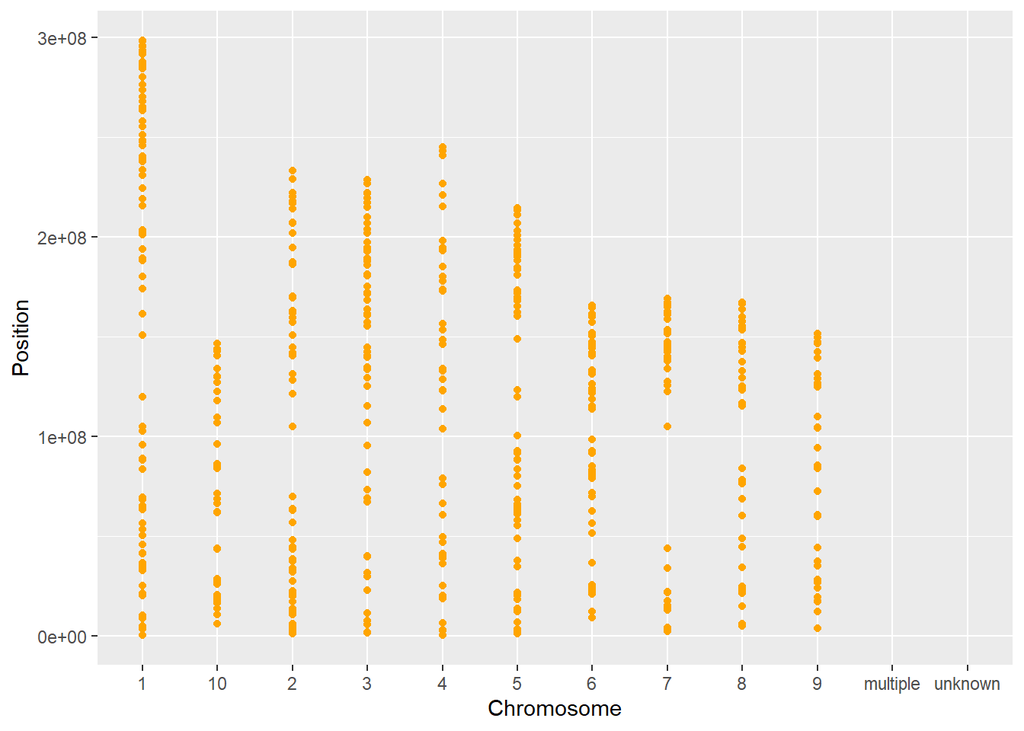

```r
#editing data
maize_pivot <- maize_combined %>%
  pivot_longer(cols = !1:3, names_to = "ID")

maize_pivot$zygosity <- ifelse(maize_pivot$value %in% c("A/A","G/G", "T/T", "C/C"), "homozygous",
                               ifelse(maize_pivot$value %in% c("?/?"), "unknown", "heterozygous"))

teosinte_pivot <- teosinte_combined %>%
  pivot_longer(cols = !1:3, names_to = "ID")

teosinte_pivot$zygosity <- ifelse(teosinte_pivot$value %in% c("A/A","G/G", "T/T", "C/C"), "homozygous",
                               ifelse(teosinte_pivot$value %in% c("?/?"), "unknown", "heterozygous"))


maize_pivot$species <- "maize"
teosinte_pivot$species <- "teosinte"
complete<- rbind(maize_pivot, teosinte_pivot)

#SNPs per chromosome
ggplot(maize_pivot, aes(x = Chromosome, y = Position)) +
  geom_point(color = "orange")
```

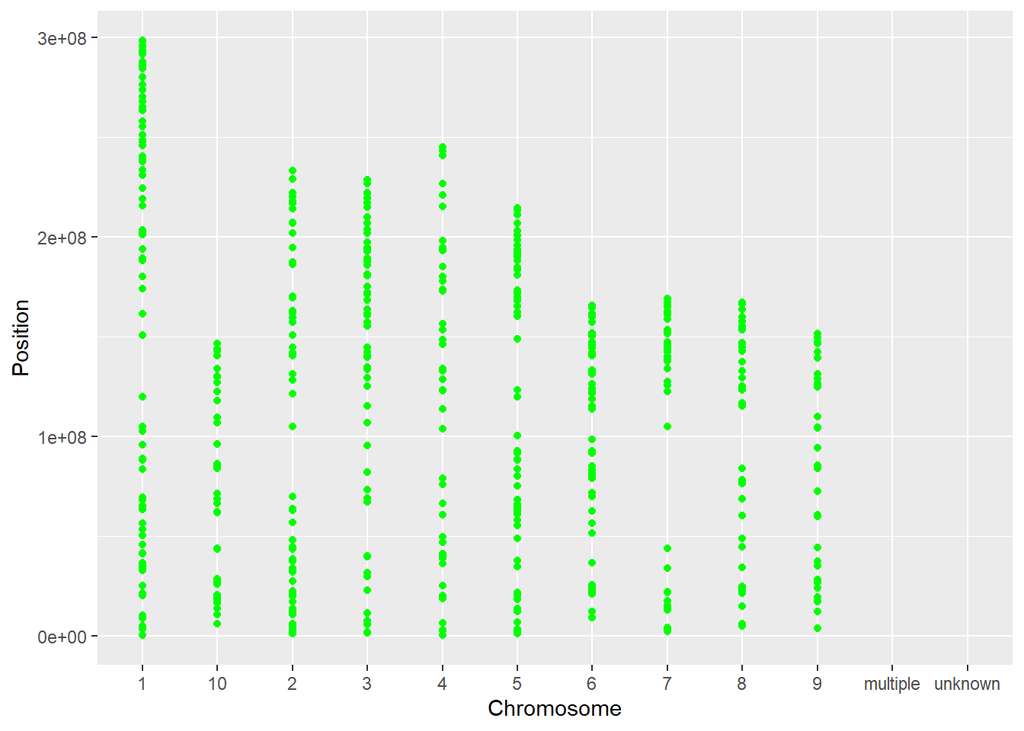

```r
ggplot(teosinte_pivot, aes (x = Chromosome, y = Position)) +
  geom_point(color = "green")
```

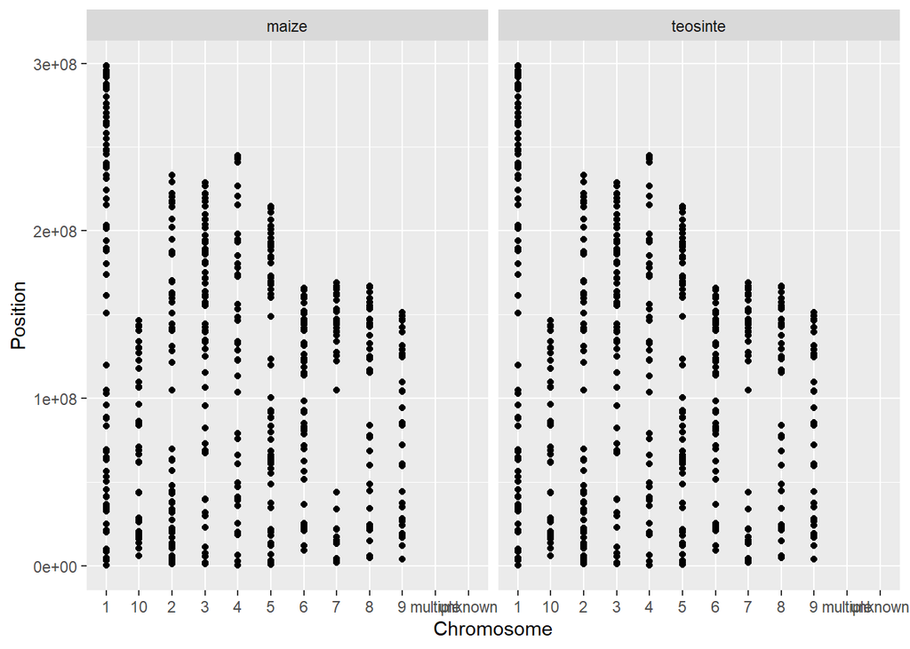

```r
ggplot(complete, aes (x = Chromosome, y = Position)) +
  geom_point() +
  facet_wrap(~species)
```

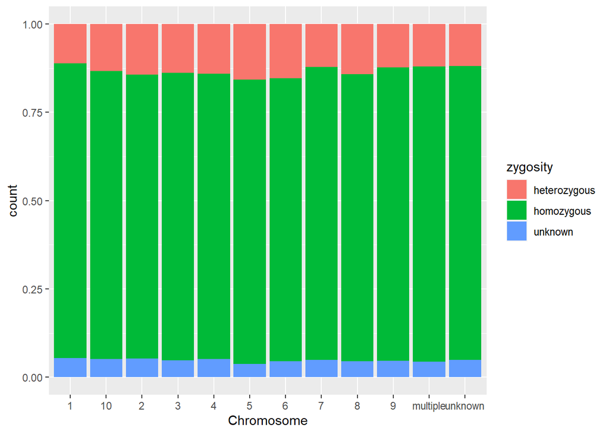

```r
#Missing data and amount of heterozygosity

ggplot(maize_pivot) +
  geom_bar(aes(x = Chromosome, fill = zygosity), position = "fill")
```

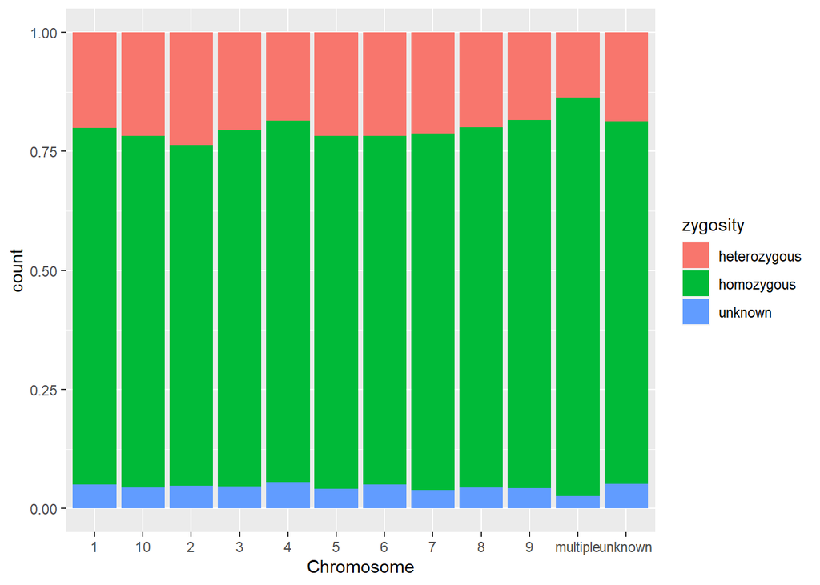

```r
ggplot(teosinte_pivot) +
  geom_bar(aes(x = Chromosome, fill = zygosity), position = "fill")
```

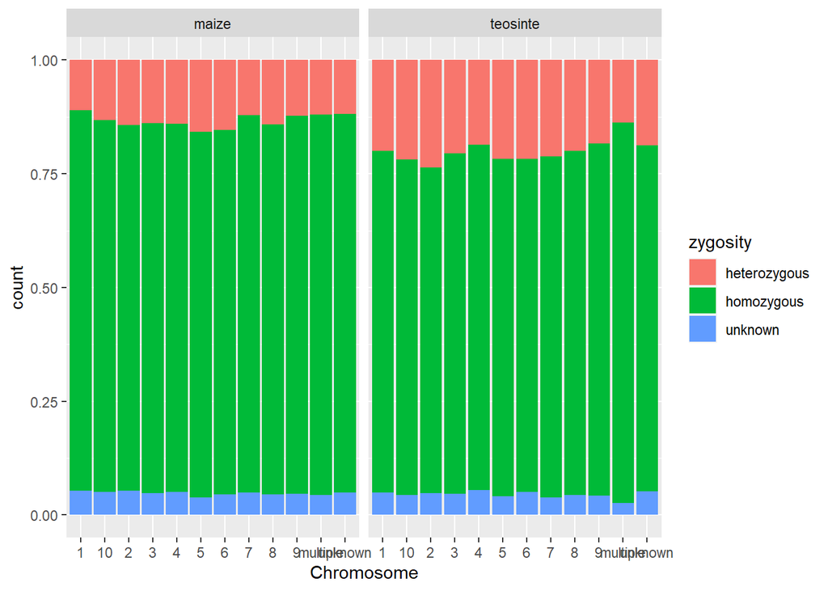

```r
ggplot(complete) +
  geom_bar(aes(x = Chromosome, fill = zygosity), position = "fill") +
  facet_wrap(~species)
```

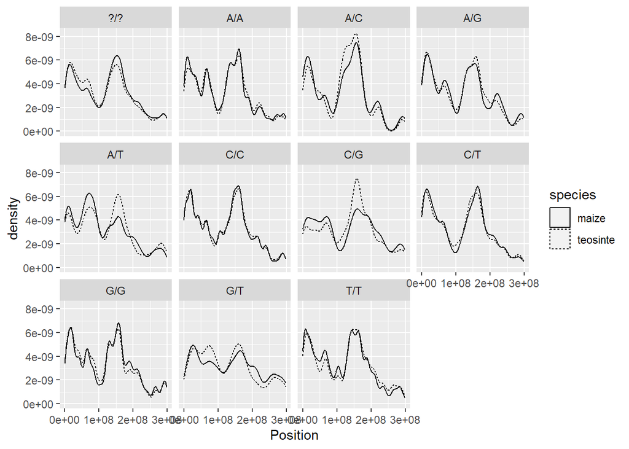

```r
#Your own visualization

ggplot(complete) +
  geom_density(aes(x = Position, linetype = species)) +
  facet_wrap(~value)
```

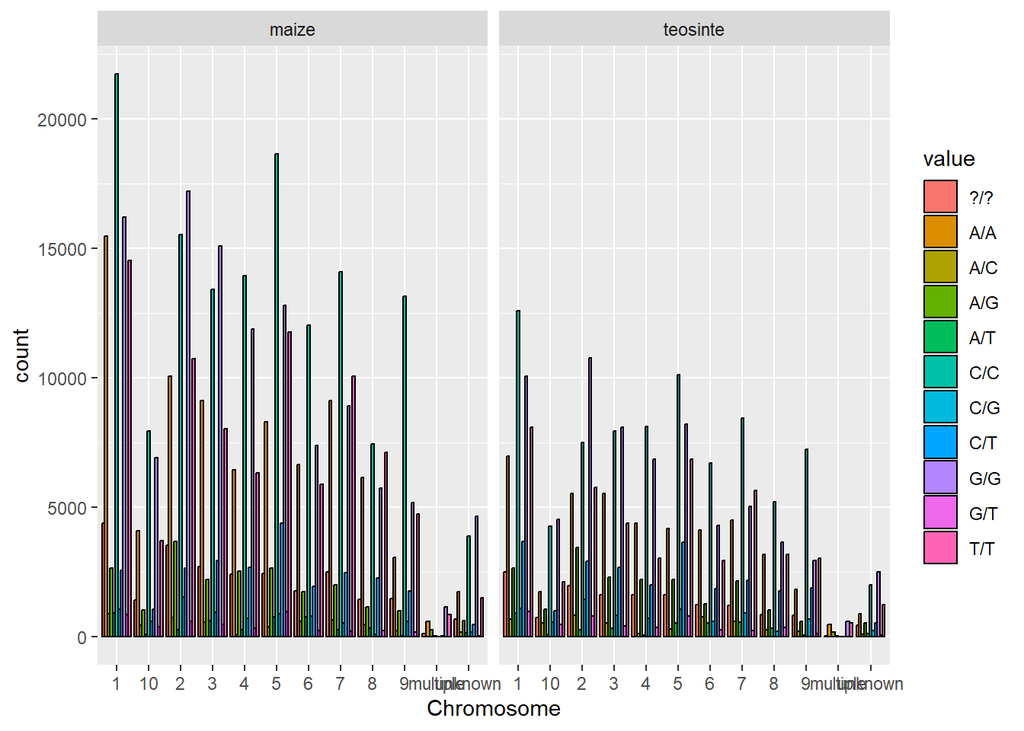

```r
ggplot(complete) +
  geom_bar(aes(x = Chromosome, fill = value), position = "dodge", color = "black") +
  facet_wrap(~species)
```

I started off this section with editing my data frames in order to visualize the data. I pivoted the maize and teosinte columns and then added a new column specifying whether a site was homozygous, heterozygous, or unknown. I also added a column in both data frames specifying if the values were “maize” or “teosinte” and then combined the two frames into one. I then used this combined frame to look at the SNP positions across chromosomes and to look at the missing data and amount of heterozygosity. For my own visualization, I created a graph that looks at the density of each site across SNP positions separated by maize or teosinte. I made a second plot that compares the number of sites within and across chromosomes separated by species.